# Cross-population heterogeneity analysis

## 3.4 PP

**Variant counts by population**

| population | variants |
| --- | --- |
| AFR | 188 |
| AMR | 188 |
| EAS | 188 |
| EUR | 188 |
| SAS | 188 |
| UGR | 188 |

**Overall heterogeneity summary**

| variants_tested | bonferroni_threshold | nominal_Q_p_lt_0_05 | bonferroni_significant | FDR_lt_0_05 | smallest_Q_p | smallest_FDR |
| --- | --- | --- | --- | --- | --- | --- |
| 188 | 0.00027 | 35 | 7 | 15 | 0 | 2e-05 |

**Transferability versus EUR (SNPs oriented to the EUR effect-increasing allele)**

| pop | n_snps | ivw_slope | ivw_slope_se | ivw_slope_lci | ivw_slope_uci | sign_concordance | pearson_r |
| --- | --- | --- | --- | --- | --- | --- | --- |
| AFR | 188 | 1.131 | 0.092 | 0.950 | 1.312 | 0.734 | 0.125 |
| AMR | 188 | 0.976 | 0.057 | 0.864 | 1.088 | 0.878 | 0.202 |
| EAS | 188 | 1.085 | 0.022 | 1.043 | 1.127 | 0.968 | 0.300 |
| SAS | 188 | 0.898 | 0.099 | 0.703 | 1.093 | 0.755 | 0.173 |
| UGR | 188 | 1.164 | 0.150 | 0.871 | 1.458 | 0.691 | -0.040 |

**SNPs passing this trait’s Bonferroni threshold**

| snpid | n_pop | beta_fixed | se_fixed | Q | Qdf | Qpval | fdr |
| --- | --- | --- | --- | --- | --- | --- | --- |
| 3:53558012_A_G | 6 | 0.23224 | 0.02842 | 40.82132 | 5 | 0.00000 | 0.00002 |
| 2:26912079_A_C | 6 | -0.25845 | 0.02756 | 34.79725 | 5 | 0.00000 | 0.00016 |
| 4:81182554_C_T | 6 | 0.37870 | 0.02873 | 29.54998 | 5 | 0.00002 | 0.00113 |
| 1:11865804_A_G | 6 | 0.35009 | 0.03657 | 28.26019 | 5 | 0.00003 | 0.00133 |
| 3:27598649_C_T | 6 | 0.40301 | 0.03644 | 28.05609 | 5 | 0.00004 | 0.00133 |
| 17:6524298_A_T | 6 | 0.25406 | 0.02721 | 24.46265 | 5 | 0.00018 | 0.00502 |
| 10:96023077_C_T | 6 | -0.26090 | 0.02653 | 24.33771 | 5 | 0.00019 | 0.00502 |

**Nominally heterogeneous SNPs (Q p < 0.05): per-population Q contributions**

| AFR | AMR | EAS | EUR | SAS | UGR | snpid |
| --- | --- | --- | --- | --- | --- | --- |
| 0.95989 | 0.04825 | 0.01673 | 0.00096 | 0.41999 | 0.62220 | 10:104867686_C_T |
| 0.04046 | 0.87067 | 0.90132 | 0.53622 | 0.00426 | 0.64775 | 10:30317073_A_G |
| 0.56130 | 0.74282 | 0.00000 | 0.00002 | 0.61484 | 0.16396 | 10:96023077_C_T |
| 0.21325 | 0.48217 | 0.00737 | 0.00232 | 0.36282 | 0.43575 | 12:115552437_A_G |
| 0.39865 | 0.03940 | 0.07526 | 0.12190 | 0.09964 | 0.51799 | 14:23861811_A_G |
| 0.07602 | 0.95867 | 0.00233 | 0.01603 | 0.31104 | 0.38725 | 15:81010249_A_G |
| 0.96247 | 0.89879 | 0.01813 | 0.02257 | 0.20294 | 0.03060 | 16:58615578_A_T |
| 0.95173 | 0.16647 | 0.10817 | 0.02880 | 0.49865 | 0.01034 | 16:65274433_A_C |
| 0.06944 | 0.13559 | 0.12766 | 0.10497 | 0.75838 | 0.01008 | 17:1958609_C_T |
| 0.85653 | 0.12656 | 0.00067 | 0.00896 | 0.77580 | 0.80462 | 17:45043508_C_T |
| 0.00341 | 0.61134 | 0.22405 | 0.44833 | 0.35570 | 0.09517 | 17:60765043_C_T |
| 0.19388 | 0.00041 | 0.24182 | 0.91493 | 0.01657 | 0.87522 | 17:6473828_C_T |
| 0.00788 | 0.00043 | 0.16814 | 0.87766 | 0.07480 | 0.48937 | 17:6524298_A_T |
| 0.00266 | 0.47334 | 0.13028 | 0.42836 | 0.58333 | 0.14659 | 19:15266928_G_T |
| 0.10116 | 0.15878 | 0.14594 | 0.44034 | 0.20013 | 0.04068 | 19:2161443_A_G |
| 0.90169 | 0.17963 | 0.00011 | 0.00009 | 0.68901 | 0.60656 | 1:10796547_A_G |
| 0.13376 | 0.07592 | 0.00001 | 0.00000 | 0.26826 | 0.28658 | 1:11865804_A_G |
| 0.64325 | 0.29215 | 0.00000 | 0.00000 | 0.17015 | 0.07559 | 2:26912079_A_C |
| 0.29792 | 0.01992 | 0.23751 | 0.02475 | 0.11622 | 0.55220 | 2:86400824_A_G |
| 0.99992 | 0.98822 | 0.00000 | 0.00000 | 0.94192 | 0.91770 | 3:27598649_C_T |
| 0.67451 | 0.02418 | 0.00000 | 0.00000 | 0.10711 | 0.07067 | 3:53558012_A_G |
| 0.59523 | 0.29784 | 0.84025 | 0.49221 | 0.35680 | 0.00231 | 4:1354306_G_T |
| 0.20187 | 0.01386 | 0.35646 | 0.58556 | 0.00388 | 0.23989 | 4:146821725_C_T |
| 0.17632 | 0.10204 | 0.00522 | 0.05526 | 0.63809 | 0.04991 | 4:54800759_C_T |
| 0.19898 | 0.51863 | 0.00000 | 0.00000 | 0.81880 | 0.49339 | 4:81182554_C_T |
| 0.14376 | 0.29727 | 0.00403 | 0.02156 | 0.34595 | 0.26005 | 5:122475437_C_T |
| 0.60394 | 0.91627 | 0.00001 | 0.00014 | 0.35748 | 0.12890 | 6:122193876_A_G |
| 0.57821 | 0.29386 | 0.00038 | 0.00349 | 0.61939 | 0.87734 | 6:159682206_C_T |
| 0.80844 | 0.33392 | 0.81278 | 0.84500 | 0.06581 | 0.00021 | 6:25291457_A_G |
| 0.50614 | 0.68436 | 0.00401 | 0.02008 | 0.55406 | 0.14523 | 7:46282123_G_T |
| 0.08570 | 0.22778 | 0.00017 | 0.00214 | 0.72020 | 0.99159 | 8:120466959_C_T |
| 0.29531 | 0.00008 | 0.66105 | 0.03571 | 0.98552 | 0.71683 | 8:124552303_A_G |
| 0.21986 | 0.14666 | 0.00002 | 0.00003 | 0.80254 | 0.80288 | 8:143992218_A_G |
| 0.84127 | 0.00894 | 0.03534 | 0.26977 | 0.18671 | 0.83834 | 8:25889267_C_T |
| 0.58539 | 0.07009 | 0.08844 | 0.00614 | 0.09079 | 0.09055 | 8:32432796_G_T |

**Per-population Q contribution plot** (method: loo)

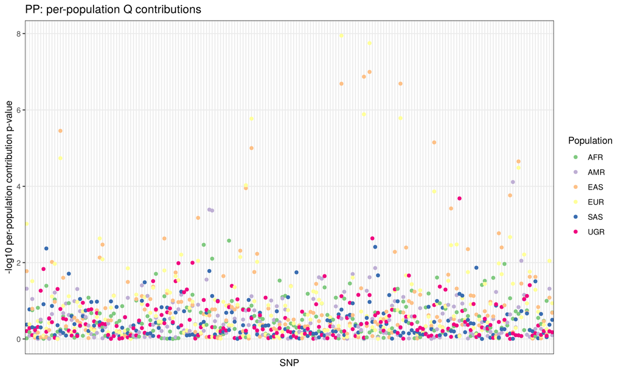

**QQ plot and genomic inflation estimates for per-population Q contributions**

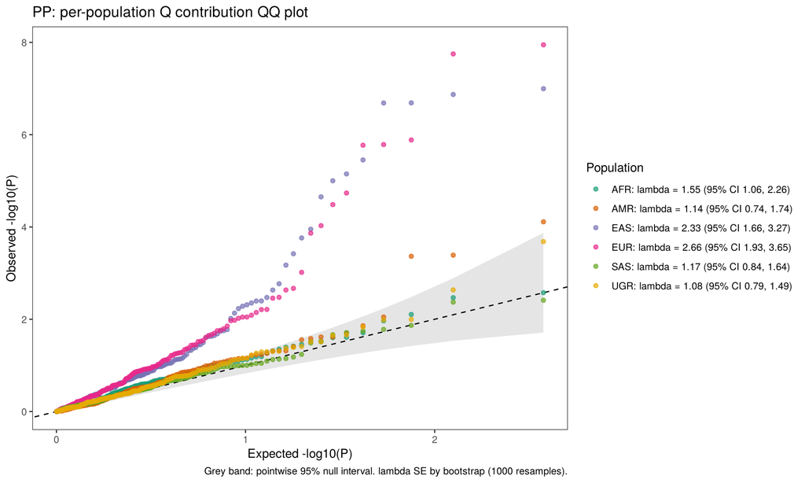

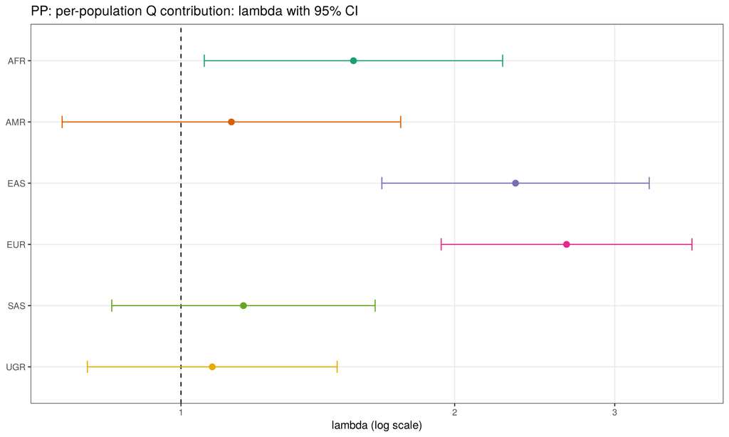

Genomic inflation (lambda) by population with standard error, 95% CI and Wald test of lambda = 1 (CI and test on the log scale; estimates from fewer than ~50 SNPs are imprecise)

| Population | n_snps | lambda | lambda_se | lambda_lci | lambda_uci | p_lambda_eq_1 |
| --- | --- | --- | --- | --- | --- | --- |
| AFR | 188 | 1.548 | 0.298 | 1.061 | 2.259 | 0.023 |
| AMR | 188 | 1.136 | 0.249 | 0.740 | 1.744 | 0.559 |
| EAS | 188 | 2.334 | 0.403 | 1.663 | 3.274 | 0.000 |
| EUR | 188 | 2.655 | 0.430 | 1.933 | 3.648 | 0.000 |
| SAS | 188 | 1.171 | 0.199 | 0.839 | 1.635 | 0.353 |
| UGR | 188 | 1.082 | 0.175 | 0.789 | 1.485 | 0.624 |

**Population-specific estimates for Bonferroni-significant SNPs**

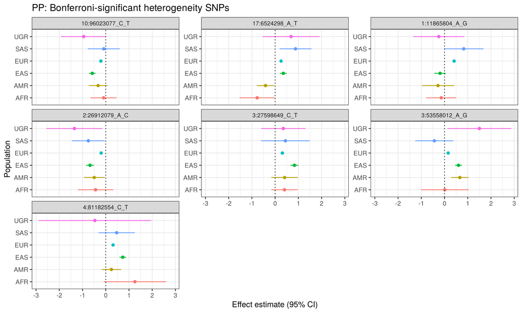

**Population-level Q contribution summary**

| population | variants_with_estimate | fraction_contribution_p_lt_0_05 |
| --- | --- | --- |
| EUR | 188 | 0.213 |
| EAS | 188 | 0.202 |
| AFR | 188 | 0.074 |
| AMR | 188 | 0.074 |
| UGR | 188 | 0.074 |
| SAS | 188 | 0.048 |

### 3.4.1 Expected versus observed replication: all exposure SNPs

EUR discovery SNPs with p < 5e-08; replication significance alpha = 0.05

| comparison | n_discovery | n_paired | nsnp | metric | datum | value | pdiff |
| --- | --- | --- | --- | --- | --- | --- | --- |
| EUR vs AFR | 175 | 175 | 175 | Sign | Expected | 131.58559 | NA |
| EUR vs AFR | 175 | 175 | 175 | Sign | Observed | 128.00000 | 0.54023 |
| EUR vs AFR | 175 | 175 | 175 | P-value | Expected | 22.30361 | NA |
| EUR vs AFR | 175 | 175 | 175 | P-value | Observed | 32.00000 | 0.04020 |
| EUR vs AMR | 175 | 175 | 175 | Sign | Expected | 152.09845 | NA |
| EUR vs AMR | 175 | 175 | 175 | Sign | Observed | 152.00000 | 1.00000 |
| EUR vs AMR | 175 | 175 | 175 | P-value | Expected | 43.13620 | NA |
| EUR vs AMR | 175 | 175 | 175 | P-value | Observed | 45.00000 | 0.72629 |
| EUR vs EAS | 175 | 175 | 175 | Sign | Expected | 171.82918 | NA |
| EUR vs EAS | 175 | 175 | 175 | Sign | Observed | 169.00000 | 0.14100 |
| EUR vs EAS | 175 | 175 | 175 | P-value | Expected | 133.35392 | NA |
| EUR vs EAS | 175 | 175 | 175 | P-value | Observed | 132.00000 | 0.79046 |
| EUR vs SAS | 175 | 175 | 175 | Sign | Expected | 131.09558 | NA |
| EUR vs SAS | 175 | 175 | 175 | Sign | Observed | 131.00000 | 1.00000 |
| EUR vs SAS | 175 | 175 | 175 | P-value | Expected | 20.40744 | NA |
| EUR vs SAS | 175 | 175 | 175 | P-value | Observed | 20.00000 | 1.00000 |
| EUR vs UGR | 175 | 175 | 175 | Sign | Expected | 116.98432 | NA |
| EUR vs UGR | 175 | 175 | 175 | Sign | Observed | 120.00000 | 0.68822 |
| EUR vs UGR | 175 | 175 | 175 | P-value | Expected | 13.83536 | NA |
| EUR vs UGR | 175 | 175 | 175 | P-value | Observed | 18.00000 | 0.25983 |

**Variants with expected-but-not-observed replication**

| comparison | snpid | expected_power | observed_sig | replication_fail | expected_sign | observed_sign | sign_fail |
| --- | --- | --- | --- | --- | --- | --- | --- |
| EUR vs AMR | 2:164940497_C_T | 0.49137 | FALSE | FALSE | 0.97370 | FALSE | TRUE |
| EUR vs EAS | 17:45043508_C_T | 0.99825 | FALSE | TRUE | 1.00000 | TRUE | FALSE |
| EUR vs EAS | 1:11865804_A_G | 0.89755 | FALSE | FALSE | 0.99938 | FALSE | TRUE |
| EUR vs EAS | 5:158220193_A_G | 0.95928 | FALSE | TRUE | 0.99989 | TRUE | FALSE |
| EUR vs EAS | 6:122193876_A_G | 1.00000 | FALSE | TRUE | 1.00000 | TRUE | FALSE |
| EUR vs EAS | 6:159682206_C_T | 0.96894 | FALSE | TRUE | 0.99993 | FALSE | TRUE |
| EUR vs EAS | 8:120466959_C_T | 0.89047 | FALSE | FALSE | 0.99929 | FALSE | TRUE |

### 3.4.2 Drug-target subset heterogeneity

Tests: 11; Bonferroni threshold: 0.0045455; significant SNPs: 2

**Summary by drug class**

| Drug | n_snps | n_nominal_Q_p_lt_0_05 | n_bonferroni_significant | proportion_FDR_lt_0_05 | median_Q_p | median_FDR | min_FDR |
| --- | --- | --- | --- | --- | --- | --- | --- |
| CCB | 10 | 2 | 2 | 0.2 | 0.4923 | 0.8269 | 0.0000 |
| BB | 1 | 0 | 0 | 0.0 | 0.1460 | 0.5352 | 0.5352 |

**Drug-target SNPs passing this subset’s Bonferroni threshold**

| snpid | Drug | n_pop | beta_fixed | se_fixed | Q | Qdf | Qpval | fdr |
| --- | --- | --- | --- | --- | --- | --- | --- | --- |
| 3:53558012_A_G | CCB | 6 | 0.23224 | 0.02842 | 40.82132 | 5 | 0.00000 | 0.00000 |
| 17:6524298_A_T | CCB | 6 | 0.25406 | 0.02721 | 24.46265 | 5 | 0.00018 | 0.00097 |

**Nominal drug-target heterogeneity: per-population Q contributions**

| AFR | AMR | EAS | EUR | SAS | UGR | snpid | Drug |
| --- | --- | --- | --- | --- | --- | --- | --- |
| 0.00788 | 0.00043 | 0.16814 | 0.87766 | 0.07480 | 0.48937 | 17:6524298_A_T | CCB |
| 0.67451 | 0.02418 | 0.00000 | 0.00000 | 0.10711 | 0.07067 | 3:53558012_A_G | CCB |

**Drug-target per-population Q contribution plot**

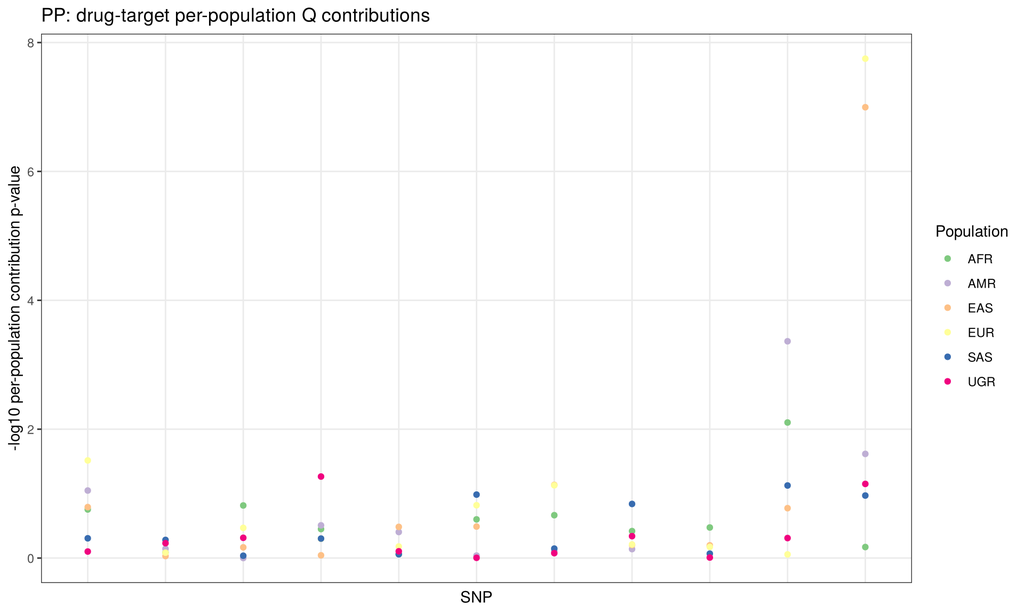

**Drug-target QQ plot and genomic inflation estimates**

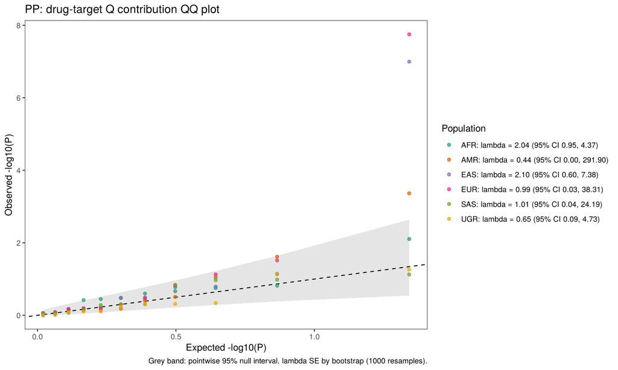

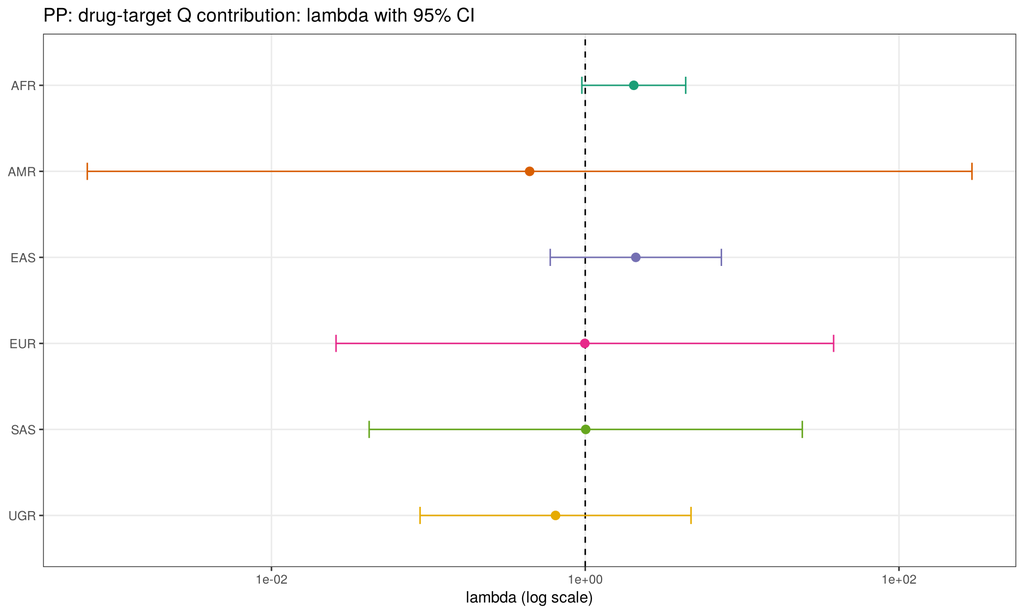

Genomic inflation (lambda) by population with standard error, 95% CI and Wald test of lambda = 1 (CI and test on the log scale; estimates from fewer than ~50 SNPs are imprecise)

| Population | n_snps | lambda | lambda_se | lambda_lci | lambda_uci | p_lambda_eq_1 |
| --- | --- | --- | --- | --- | --- | --- |
| AFR | 11 | 2.039 | 0.793 | 0.952 | 4.370 | 0.067 |
| AMR | 11 | 0.442 | 1.465 | 0.001 | 291.902 | 0.805 |
| EAS | 11 | 2.101 | 1.346 | 0.598 | 7.378 | 0.247 |
| EUR | 11 | 0.994 | 1.852 | 0.026 | 38.310 | 0.997 |
| SAS | 11 | 1.007 | 1.634 | 0.042 | 24.190 | 0.996 |
| UGR | 11 | 0.647 | 0.656 | 0.089 | 4.726 | 0.668 |

**Population-specific estimates for drug-target Bonferroni hits**

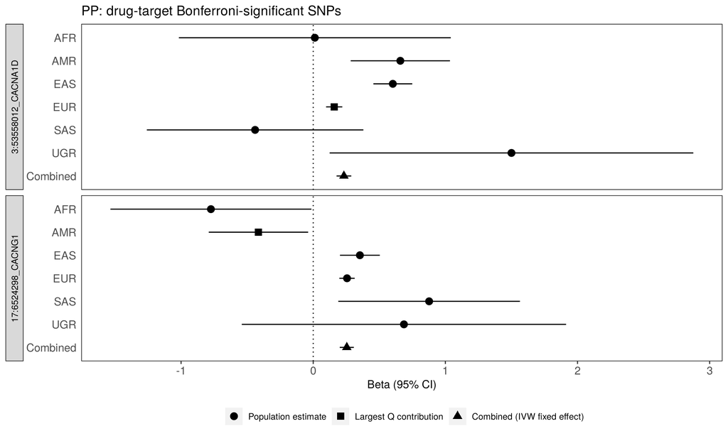

**Per-population Q contribution fractions by drug class**

| Drug | population | variants_with_estimate | fraction_contribution_p_lt_0_05 |
| --- | --- | --- | --- |
| BB | EUR | 1 | 1.0 |
| BB | AFR | 1 | 0.0 |
| BB | AMR | 1 | 0.0 |
| BB | EAS | 1 | 0.0 |
| BB | SAS | 1 | 0.0 |
| BB | UGR | 1 | 0.0 |
| CCB | AMR | 10 | 0.2 |
| CCB | AFR | 10 | 0.1 |
| CCB | EAS | 10 | 0.1 |
| CCB | EUR | 10 | 0.1 |
| CCB | SAS | 10 | 0.0 |
| CCB | UGR | 10 | 0.0 |

### 3.4.3 Expected versus observed replication: drug-target SNPs

Drug-target EUR discovery SNPs with p < 0.05; replication significance alpha = 0.05

| comparison | n_discovery | n_paired | nsnp | metric | datum | value | pdiff |
| --- | --- | --- | --- | --- | --- | --- | --- |
| EUR vs AFR | 11 | 11 | 11 | Sign | Expected | 7.64055 | NA |
| EUR vs AFR | 11 | 11 | 11 | Sign | Observed | 9.00000 | 0.52139 |
| EUR vs AFR | 11 | 11 | 11 | P-value | Expected | 0.95810 | NA |
| EUR vs AFR | 11 | 11 | 11 | P-value | Observed | 3.00000 | 0.06411 |
| EUR vs AMR | 11 | 11 | 11 | Sign | Expected | 8.79997 | NA |
| EUR vs AMR | 11 | 11 | 11 | Sign | Observed | 10.00000 | 0.70472 |
| EUR vs AMR | 11 | 11 | 11 | P-value | Expected | 1.62849 | NA |
| EUR vs AMR | 11 | 11 | 11 | P-value | Observed | 4.00000 | 0.06668 |
| EUR vs EAS | 11 | 11 | 11 | Sign | Expected | 10.53736 | NA |
| EUR vs EAS | 11 | 11 | 11 | Sign | Observed | 11.00000 | 1.00000 |
| EUR vs EAS | 11 | 11 | 11 | P-value | Expected | 6.10446 | NA |
| EUR vs EAS | 11 | 11 | 11 | P-value | Observed | 7.00000 | 0.76438 |
| EUR vs SAS | 11 | 11 | 11 | Sign | Expected | 7.59114 | NA |
| EUR vs SAS | 11 | 11 | 11 | Sign | Observed | 9.00000 | 0.52052 |
| EUR vs SAS | 11 | 11 | 11 | P-value | Expected | 0.90564 | NA |
| EUR vs SAS | 11 | 11 | 11 | P-value | Observed | 2.00000 | 0.22782 |
| EUR vs UGR | 11 | 11 | 11 | Sign | Expected | 6.86365 | NA |
| EUR vs UGR | 11 | 11 | 11 | Sign | Observed | 8.00000 | 0.55204 |
| EUR vs UGR | 11 | 11 | 11 | P-value | Expected | 0.70252 | NA |
| EUR vs UGR | 11 | 11 | 11 | P-value | Observed | 1.00000 | 0.51614 |

## 3.5 SBP

**Variant counts by population**

| population | variants |
| --- | --- |
| AFR | 154 |
| AMR | 154 |
| EAS | 154 |
| EUR | 154 |
| SAS | 154 |
| UGR | 154 |

**Overall heterogeneity summary**

| variants_tested | bonferroni_threshold | nominal_Q_p_lt_0_05 | bonferroni_significant | FDR_lt_0_05 | smallest_Q_p | smallest_FDR |
| --- | --- | --- | --- | --- | --- | --- |
| 154 | 0.00032 | 34 | 9 | 17 | 0 | 1e-05 |

**Transferability versus EUR (SNPs oriented to the EUR effect-increasing allele)**

| pop | n_snps | ivw_slope | ivw_slope_se | ivw_slope_lci | ivw_slope_uci | sign_concordance | pearson_r |
| --- | --- | --- | --- | --- | --- | --- | --- |
| AFR | 154 | 1.182 | 0.136 | 0.915 | 1.448 | 0.688 | 0.150 |
| AMR | 154 | 1.005 | 0.020 | 0.965 | 1.045 | 1.000 | 0.427 |
| EAS | 154 | 1.042 | 0.018 | 1.006 | 1.077 | 1.000 | 0.419 |
| SAS | 154 | 1.058 | 0.142 | 0.779 | 1.337 | 0.656 | 0.334 |
| UGR | 154 | 1.082 | 0.146 | 0.796 | 1.368 | 0.721 | -0.032 |

**SNPs passing this trait’s Bonferroni threshold**

| snpid | n_pop | beta_fixed | se_fixed | Q | Qdf | Qpval | fdr |
| --- | --- | --- | --- | --- | --- | --- | --- |
| 16:53800954_C_T | 6 | 0.45252 | 0.04960 | 41.63612 | 5 | 0.00000 | 0.00001 |
| 4:81182554_C_T | 6 | 1.15094 | 0.04684 | 41.15512 | 5 | 0.00000 | 0.00001 |
| 1:155123837_C_G | 6 | 0.33504 | 0.04930 | 36.27317 | 5 | 0.00000 | 0.00004 |
| 1:11876300_G_T | 6 | -0.76377 | 0.06441 | 35.89507 | 5 | 0.00000 | 0.00004 |
| 8:143992218_A_G | 6 | 0.41724 | 0.04396 | 32.22751 | 5 | 0.00001 | 0.00016 |
| 3:53545622_C_T | 6 | -0.45617 | 0.04420 | 27.58433 | 5 | 0.00004 | 0.00109 |
| 2:26911745_C_T | 6 | 0.80565 | 0.04700 | 27.31274 | 5 | 0.00005 | 0.00109 |
| 1:10796866_C_T | 6 | 0.57352 | 0.04517 | 26.83690 | 5 | 0.00006 | 0.00118 |
| 7:27245996_C_T | 6 | -0.90802 | 0.06096 | 23.87515 | 5 | 0.00023 | 0.00393 |

**Nominally heterogeneous SNPs (Q p < 0.05): per-population Q contributions**

| AFR | AMR | EAS | EUR | SAS | UGR | snpid |
| --- | --- | --- | --- | --- | --- | --- |
| 0.00588 | 0.95017 | 0.26018 | 0.60210 | 0.02380 | 0.03283 | 10:45375530_C_T |
| 0.91109 | 0.95285 | 0.00025 | 0.00315 | 0.89404 | 0.40115 | 10:96014622_C_G |
| 0.58756 | 0.40377 | 0.48553 | 0.93440 | 0.08894 | 0.00370 | 11:16373664_C_T |
| 0.40728 | 0.04230 | 0.01076 | 0.00022 | 0.37284 | 0.95053 | 12:12878349_C_G |
| 0.34209 | 0.00003 | 0.00008 | 0.00000 | 0.38122 | 0.29387 | 16:53800954_C_T |
| 0.90489 | 0.00003 | 0.06174 | 0.08038 | 0.67795 | 0.18827 | 16:58553348_C_T |
| 0.26315 | 0.02601 | 0.19911 | 0.00241 | 0.83899 | 0.31144 | 16:73606553_C_G |
| 0.32731 | 0.00171 | 0.35362 | 0.05830 | 0.25497 | 0.99884 | 17:1331647_A_G |
| 0.84076 | 0.66809 | 0.00007 | 0.00081 | 0.86784 | 0.23713 | 17:43177951_C_T |
| 0.27648 | 0.46505 | 0.00115 | 0.00049 | 0.76183 | 0.93729 | 17:45011157_C_T |
| 0.21420 | 0.00144 | 0.08274 | 0.44026 | 0.11064 | 0.68339 | 19:17225128_A_G |
| 0.08858 | 0.01242 | 0.61131 | 0.01820 | 0.22966 | 0.13740 | 19:18449238_A_G |
| 0.14513 | 0.88691 | 0.00001 | 0.00029 | 0.10930 | 0.31608 | 1:10796866_C_T |
| 0.57320 | 0.02115 | 0.00000 | 0.00000 | 0.09187 | 0.81881 | 1:11876300_G_T |
| 0.38407 | 0.42768 | 0.00000 | 0.00000 | 0.73364 | 0.91684 | 1:155123837_C_G |
| 0.96101 | 0.10829 | 0.01778 | 0.00103 | 0.55547 | 0.68624 | 1:228189495_C_T |
| 0.34044 | 0.18044 | 0.00007 | 0.02291 | 0.26701 | 0.28394 | 20:50108980_A_G |
| 0.00055 | 0.04502 | 0.81000 | 0.17011 | 0.99321 | 0.18352 | 20:62703490_C_T |
| 0.40777 | 0.00017 | 0.61367 | 0.00054 | 0.05135 | 0.49838 | 22:32082345_C_T |
| 0.00723 | 0.26903 | 0.17797 | 0.02279 | 0.40587 | 0.94051 | 2:165008166_C_G |
| 0.19921 | 0.27807 | 0.00152 | 0.14823 | 0.36980 | 0.75397 | 2:19729795_A_C |
| 0.34779 | 0.04053 | 0.00147 | 0.00000 | 0.04585 | 0.09534 | 2:26911745_C_T |
| 0.04462 | 0.00392 | 0.75860 | 0.00959 | 0.65423 | 0.02808 | 2:27691588_A_C |
| 0.41576 | 0.56580 | 0.06068 | 0.03177 | 0.22070 | 0.00017 | 2:86300308_C_T |
| 0.57717 | 0.81840 | 0.01588 | 0.03674 | 0.98899 | 0.01637 | 3:27562988_C_T |
| 0.41103 | 0.53499 | 0.00000 | 0.00001 | 0.75107 | 0.21597 | 3:53545622_C_T |
| 0.87495 | 0.02434 | 0.34242 | 0.54479 | 0.00193 | 0.77721 | 4:106911742_C_G |
| 0.67256 | 0.14176 | 0.00000 | 0.00000 | 0.84137 | 0.39252 | 4:81182554_C_T |
| 0.34223 | 0.00115 | 0.64481 | 0.06282 | 0.16409 | 0.68946 | 5:87988733_A_G |
| 0.88710 | 0.00336 | 0.02636 | 0.42613 | 0.91751 | 0.13233 | 6:150997401_C_T |
| 0.66389 | 0.00130 | 0.15085 | 0.24355 | 0.66835 | 0.64710 | 6:31762844_G_T |
| 0.42578 | 0.23512 | 0.01888 | 0.66208 | 0.18116 | 0.00728 | 7:150704843_A_G |
| 0.00498 | 0.09397 | 0.00008 | 0.03767 | 0.13475 | 0.89624 | 7:27245996_C_T |
| 0.14282 | 0.72889 | 0.00000 | 0.00007 | 0.51260 | 0.30441 | 8:143992218_A_G |

**Per-population Q contribution plot** (method: loo)

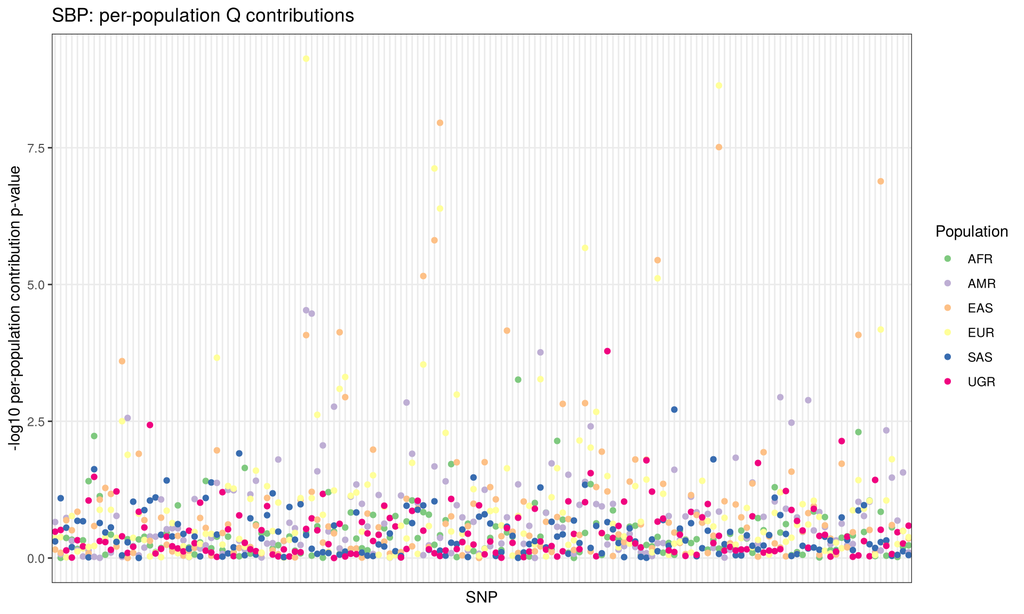

**QQ plot and genomic inflation estimates for per-population Q contributions**

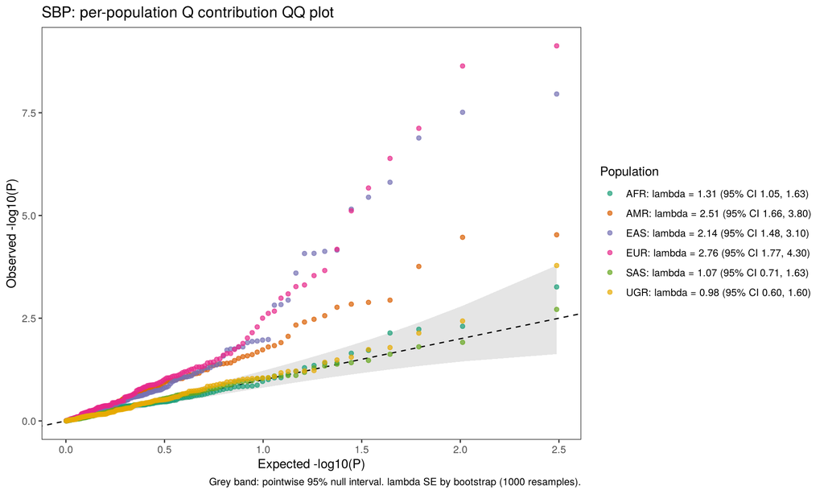

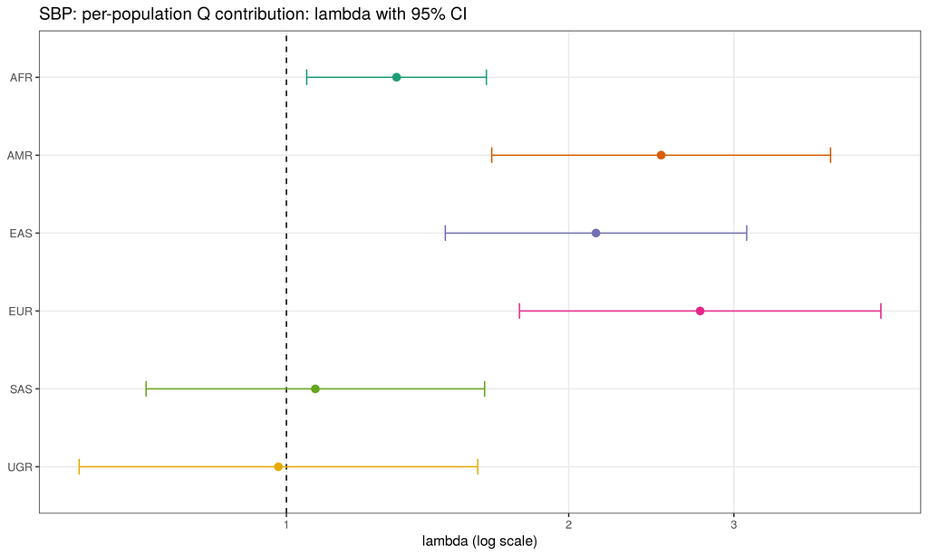

Genomic inflation (lambda) by population with standard error, 95% CI and Wald test of lambda = 1 (CI and test on the log scale; estimates from fewer than ~50 SNPs are imprecise)

| Population | n_snps | lambda | lambda_se | lambda_lci | lambda_uci | p_lambda_eq_1 |
| --- | --- | --- | --- | --- | --- | --- |
| AFR | 154 | 1.310 | 0.147 | 1.051 | 1.634 | 0.016 |
| AMR | 154 | 2.509 | 0.532 | 1.656 | 3.804 | 0.000 |
| EAS | 154 | 2.138 | 0.404 | 1.477 | 3.096 | 0.000 |
| EUR | 154 | 2.762 | 0.625 | 1.772 | 4.304 | 0.000 |
| SAS | 154 | 1.073 | 0.228 | 0.708 | 1.627 | 0.738 |
| UGR | 154 | 0.980 | 0.245 | 0.601 | 1.599 | 0.937 |

**Population-specific estimates for Bonferroni-significant SNPs**

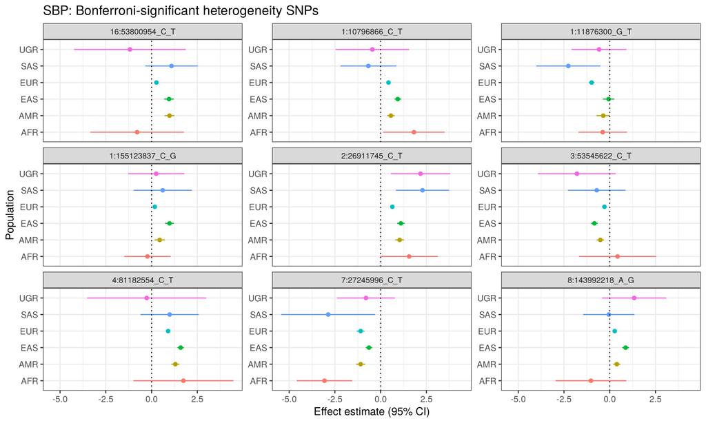

**Population-level Q contribution summary**

| population | variants_with_estimate | fraction_contribution_p_lt_0_05 |
| --- | --- | --- |
| EUR | 154 | 0.221 |
| AMR | 154 | 0.188 |
| EAS | 154 | 0.182 |
| AFR | 154 | 0.058 |
| SAS | 154 | 0.052 |
| UGR | 154 | 0.052 |

### 3.5.1 Expected versus observed replication: all exposure SNPs

EUR discovery SNPs with p < 5e-08; replication significance alpha = 0.05

| comparison | n_discovery | n_paired | nsnp | metric | datum | value | pdiff |
| --- | --- | --- | --- | --- | --- | --- | --- |
| EUR vs AFR | 100 | 100 | 100 | Sign | Expected | 72.98238 | NA |
| EUR vs AFR | 100 | 100 | 100 | Sign | Observed | 75.00000 | 0.73575 |
| EUR vs AFR | 100 | 100 | 100 | P-value | Expected | 10.39025 | NA |
| EUR vs AFR | 100 | 100 | 100 | P-value | Observed | 11.00000 | 0.86922 |
| EUR vs AMR | 100 | 100 | 100 | Sign | Expected | 99.93868 | NA |
| EUR vs AMR | 100 | 100 | 100 | Sign | Observed | 100.00000 | 1.00000 |
| EUR vs AMR | 100 | 100 | 100 | P-value | Expected | 94.11371 | NA |
| EUR vs AMR | 100 | 100 | 100 | P-value | Observed | 87.00000 | 0.00821 |
| EUR vs EAS | 100 | 100 | 100 | Sign | Expected | 99.56236 | NA |
| EUR vs EAS | 100 | 100 | 100 | Sign | Observed | 100.00000 | 1.00000 |
| EUR vs EAS | 100 | 100 | 100 | P-value | Expected | 92.31240 | NA |
| EUR vs EAS | 100 | 100 | 100 | P-value | Observed | 82.00000 | 0.00092 |
| EUR vs SAS | 100 | 100 | 100 | Sign | Expected | 72.62491 | NA |
| EUR vs SAS | 100 | 100 | 100 | Sign | Observed | 69.00000 | 0.43263 |
| EUR vs SAS | 100 | 100 | 100 | P-value | Expected | 9.91269 | NA |
| EUR vs SAS | 100 | 100 | 100 | P-value | Observed | 12.00000 | 0.50086 |
| EUR vs UGR | 100 | 100 | 100 | Sign | Expected | 71.74253 | NA |
| EUR vs UGR | 100 | 100 | 100 | Sign | Observed | 72.00000 | 1.00000 |
| EUR vs UGR | 100 | 100 | 100 | P-value | Expected | 9.61976 | NA |
| EUR vs UGR | 100 | 100 | 100 | P-value | Observed | 11.00000 | 0.61008 |

**Variants with expected-but-not-observed replication**

| comparison | snpid | expected_power | observed_sig | replication_fail | expected_sign | observed_sign | sign_fail |
| --- | --- | --- | --- | --- | --- | --- | --- |
| EUR vs AMR | 12:20368269_C_T | 0.98072 | FALSE | TRUE | 0.99997 | TRUE | FALSE |
| EUR vs AMR | 19:17225128_A_G | 0.97037 | FALSE | TRUE | 0.99994 | TRUE | FALSE |
| EUR vs AMR | 1:11876300_G_T | 0.99948 | FALSE | TRUE | 1.00000 | TRUE | FALSE |
| EUR vs AMR | 1:228189495_C_T | 0.99121 | FALSE | TRUE | 0.99999 | TRUE | FALSE |
| EUR vs AMR | 6:31762844_G_T | 0.97983 | FALSE | TRUE | 0.99997 | TRUE | FALSE |
| EUR vs EAS | 10:64564934_C_G | 0.96395 | FALSE | TRUE | 0.99991 | TRUE | FALSE |
| EUR vs EAS | 17:43177951_C_T | 0.99980 | FALSE | TRUE | 1.00000 | TRUE | FALSE |
| EUR vs EAS | 17:45011157_C_T | 0.99991 | FALSE | TRUE | 1.00000 | TRUE | FALSE |
| EUR vs EAS | 1:11876300_G_T | 0.99999 | FALSE | TRUE | 1.00000 | TRUE | FALSE |
| EUR vs EAS | 1:228189495_C_T | 0.99836 | FALSE | TRUE | 1.00000 | TRUE | FALSE |
| EUR vs EAS | 20:40261579_C_T | 0.98266 | FALSE | TRUE | 0.99998 | TRUE | FALSE |

### 3.5.2 Drug-target subset heterogeneity

Tests: 10; Bonferroni threshold: 0.005; significant SNPs: 1

**Summary by drug class**

| Drug | n_snps | n_nominal_Q_p_lt_0_05 | n_bonferroni_significant | proportion_FDR_lt_0_05 | median_Q_p | median_FDR | min_FDR |
| --- | --- | --- | --- | --- | --- | --- | --- |
| CCB | 7 | 1 | 1 | 0.1429 | 0.1995 | 0.4988 | 0.0004 |
| ACEI | 1 | 0 | 0 | 0.0000 | 0.4999 | 0.6485 | 0.6485 |
| BB | 2 | 0 | 0 | 0.0000 | 0.5997 | 0.7039 | 0.6485 |

**Drug-target SNPs passing this subset’s Bonferroni threshold**

| snpid | Drug | n_pop | beta_fixed | se_fixed | Q | Qdf | Qpval | fdr |
| --- | --- | --- | --- | --- | --- | --- | --- | --- |
| 3:53545622_C_T | CCB | 6 | -0.45617 | 0.0442 | 27.58433 | 5 | 4e-05 | 0.00044 |

**Nominal drug-target heterogeneity: per-population Q contributions**

| AFR | AMR | EAS | EUR | SAS | UGR | snpid | Drug |
| --- | --- | --- | --- | --- | --- | --- | --- |
| 0.41103 | 0.53499 | 0 | 1e-05 | 0.75107 | 0.21597 | 3:53545622_C_T | CCB |

**Drug-target per-population Q contribution plot**

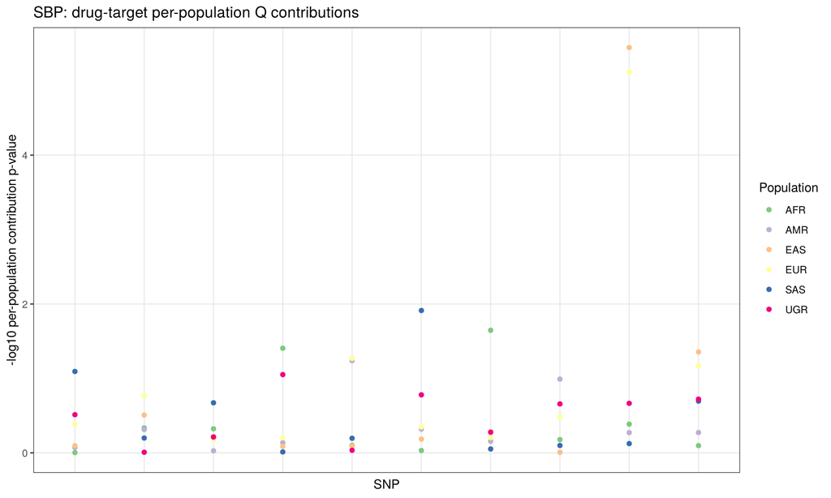

**Drug-target QQ plot and genomic inflation estimates**

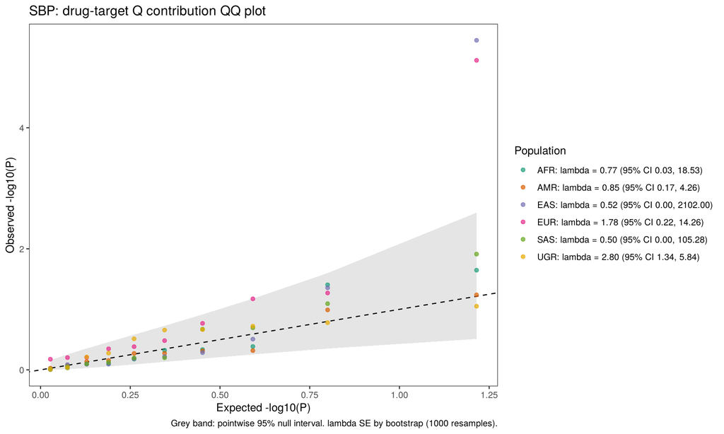

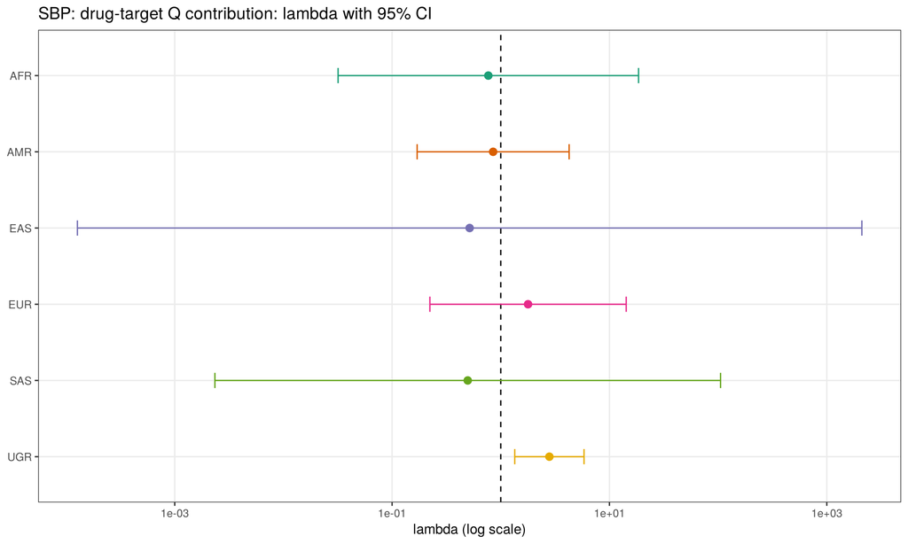

Genomic inflation (lambda) by population with standard error, 95% CI and Wald test of lambda = 1 (CI and test on the log scale; estimates from fewer than ~50 SNPs are imprecise)

| Population | n_snps | lambda | lambda_se | lambda_lci | lambda_uci | p_lambda_eq_1 |
| --- | --- | --- | --- | --- | --- | --- |
| AFR | 10 | 0.768 | 1.248 | 0.032 | 18.532 | 0.871 |
| AMR | 10 | 0.850 | 0.699 | 0.170 | 4.255 | 0.844 |
| EAS | 10 | 0.517 | 2.192 | 0.000 | 2101.998 | 0.876 |
| EUR | 10 | 1.782 | 1.891 | 0.223 | 14.263 | 0.586 |
| SAS | 10 | 0.497 | 1.357 | 0.002 | 105.276 | 0.798 |
| UGR | 10 | 2.802 | 1.049 | 1.345 | 5.837 | 0.006 |

**Population-specific estimates for drug-target Bonferroni hits**

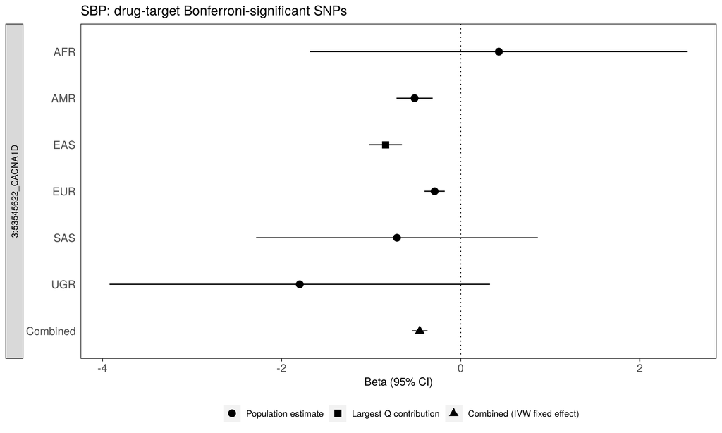

**Per-population Q contribution fractions by drug class**

| Drug | population | variants_with_estimate | fraction_contribution_p_lt_0_05 |
| --- | --- | --- | --- |
| ACEI | AFR | 1 | 0.000 |
| ACEI | AMR | 1 | 0.000 |
| ACEI | EAS | 1 | 0.000 |
| ACEI | EUR | 1 | 0.000 |
| ACEI | SAS | 1 | 0.000 |
| ACEI | UGR | 1 | 0.000 |
| BB | AFR | 2 | 0.000 |
| BB | AMR | 2 | 0.000 |
| BB | EAS | 2 | 0.000 |
| BB | EUR | 2 | 0.000 |
| BB | SAS | 2 | 0.000 |
| BB | UGR | 2 | 0.000 |
| CCB | AFR | 7 | 0.286 |
| CCB | EAS | 7 | 0.286 |
| CCB | EUR | 7 | 0.143 |
| CCB | SAS | 7 | 0.143 |
| CCB | AMR | 7 | 0.000 |
| CCB | UGR | 7 | 0.000 |

### 3.5.3 Expected versus observed replication: drug-target SNPs

Drug-target EUR discovery SNPs with p < 0.05; replication significance alpha = 0.05

| comparison | n_discovery | n_paired | nsnp | metric | datum | value | pdiff |
| --- | --- | --- | --- | --- | --- | --- | --- |
| EUR vs AFR | 9 | 9 | 9 | Sign | Expected | 6.18999 | NA |
| EUR vs AFR | 9 | 9 | 9 | Sign | Observed | 5.00000 | 0.47390 |
| EUR vs AFR | 9 | 9 | 9 | P-value | Expected | 0.83252 | NA |
| EUR vs AFR | 9 | 9 | 9 | P-value | Observed | 1.00000 | 0.58254 |
| EUR vs AMR | 9 | 9 | 9 | Sign | Expected | 8.90549 | NA |
| EUR vs AMR | 9 | 9 | 9 | Sign | Observed | 9.00000 | 1.00000 |
| EUR vs AMR | 9 | 9 | 9 | P-value | Expected | 6.54427 | NA |
| EUR vs AMR | 9 | 9 | 9 | P-value | Observed | 8.00000 | 0.45969 |
| EUR vs EAS | 9 | 9 | 9 | Sign | Expected | 8.83533 | NA |
| EUR vs EAS | 9 | 9 | 9 | Sign | Observed | 9.00000 | 1.00000 |
| EUR vs EAS | 9 | 9 | 9 | P-value | Expected | 6.23211 | NA |
| EUR vs EAS | 9 | 9 | 9 | P-value | Observed | 8.00000 | 0.29124 |
| EUR vs SAS | 9 | 9 | 9 | Sign | Expected | 5.92813 | NA |
| EUR vs SAS | 9 | 9 | 9 | Sign | Observed | 7.00000 | 0.72722 |
| EUR vs SAS | 9 | 9 | 9 | P-value | Expected | 0.66331 | NA |
| EUR vs SAS | 9 | 9 | 9 | P-value | Observed | 2.00000 | 0.13841 |
| EUR vs UGR | 9 | 9 | 9 | Sign | Expected | 6.08474 | NA |
| EUR vs UGR | 9 | 9 | 9 | Sign | Observed | 6.00000 | 1.00000 |
| EUR vs UGR | 9 | 9 | 9 | P-value | Expected | 0.77011 | NA |
| EUR vs UGR | 9 | 9 | 9 | P-value | Observed | 1.00000 | 0.55294 |

## 3.6 TG

**Variant counts by population**

| population | variants |
| --- | --- |
| AFR | 121 |
| AMR | 121 |
| EAS | 121 |
| EUR | 121 |
| SAS | 121 |
| UGR | 121 |

**Overall heterogeneity summary**

| variants_tested | bonferroni_threshold | nominal_Q_p_lt_0_05 | bonferroni_significant | FDR_lt_0_05 | smallest_Q_p | smallest_FDR |
| --- | --- | --- | --- | --- | --- | --- |
| 121 | 0.00041 | 27 | 12 | 16 | 0 | 0 |

**Transferability versus EUR (SNPs oriented to the EUR effect-increasing allele)**

| pop | n_snps | ivw_slope | ivw_slope_se | ivw_slope_lci | ivw_slope_uci | sign_concordance | pearson_r |
| --- | --- | --- | --- | --- | --- | --- | --- |
| AFR | 121 | 1.086 | 0.082 | 0.926 | 1.246 | 0.835 | 0.532 |
| AMR | 121 | 1.087 | 0.029 | 1.030 | 1.143 | 0.950 | 0.676 |
| EAS | 121 | 0.996 | 0.037 | 0.923 | 1.070 | 0.810 | 0.664 |
| SAS | 121 | 0.960 | 0.089 | 0.785 | 1.136 | 0.777 | 0.586 |
| UGR | 121 | 1.213 | 0.113 | 0.992 | 1.433 | 0.744 | 0.310 |

**SNPs passing this trait’s Bonferroni threshold**

| snpid | n_pop | beta_fixed | se_fixed | Q | Qdf | Qpval | fdr |
| --- | --- | --- | --- | --- | --- | --- | --- |
| 11:116624703_G_T | 6 | 0.10265 | 0.00213 | 185.36259 | 5 | 0.00000 | 0.00000 |
| 11:116588629_C_T | 6 | -0.06599 | 0.00255 | 129.98469 | 5 | 0.00000 | 0.00000 |
| 19:19750519_A_G | 6 | -0.03151 | 0.00685 | 81.55793 | 5 | 0.00000 | 0.00000 |
| 11:116528663_A_G | 6 | -0.05080 | 0.00327 | 45.92820 | 5 | 0.00000 | 0.00000 |
| 2:21231524_A_G | 6 | -0.07236 | 0.00249 | 43.00776 | 5 | 0.00000 | 0.00000 |
| 15:58723426_A_G | 6 | -0.05223 | 0.00242 | 35.73621 | 5 | 0.00000 | 0.00002 |
| 1:230294715_A_C | 6 | -0.04587 | 0.00210 | 32.70015 | 5 | 0.00000 | 0.00007 |
| 11:61557803_C_T | 6 | 0.04712 | 0.00214 | 32.25893 | 5 | 0.00001 | 0.00008 |
| 8:19934305_A_G | 6 | 0.03525 | 0.00267 | 31.01510 | 5 | 0.00001 | 0.00013 |
| 8:10644101_C_G | 6 | 0.03452 | 0.00257 | 23.59058 | 5 | 0.00026 | 0.00306 |
| 8:126500031_C_G | 6 | 0.09504 | 0.00210 | 23.43594 | 5 | 0.00028 | 0.00306 |
| 11:117310022_A_G | 6 | -0.02010 | 0.00314 | 23.02286 | 5 | 0.00033 | 0.00337 |

**Nominally heterogeneous SNPs (Q p < 0.05): per-population Q contributions**

| AFR | AMR | EAS | EUR | SAS | UGR | snpid |
| --- | --- | --- | --- | --- | --- | --- |
| 0.00024 | 0.03401 | 0.82810 | 0.03652 | 0.13323 | 0.97116 | 11:116486868_A_T |
| 0.63051 | 0.00000 | 0.58299 | 0.00000 | 0.24601 | 0.33184 | 11:116528663_A_G |
| 0.01623 | 0.00000 | 0.00000 | 0.00000 | 0.92080 | 0.82100 | 11:116588629_C_T |
| 0.00237 | 0.00000 | 0.00000 | 0.00000 | 0.00059 | 0.00385 | 11:116624703_G_T |
| 0.35939 | 0.00016 | 0.00356 | 0.22721 | 0.84742 | 0.23391 | 11:117310022_A_G |
| 0.04692 | 0.00001 | 0.12661 | 0.00000 | 0.03243 | 0.88358 | 11:61557803_C_T |
| 0.30880 | 0.11268 | 0.00057 | 0.00055 | 0.69007 | 0.13721 | 11:63862882_C_G |
| 0.00012 | 0.99307 | 0.01232 | 0.00020 | 0.17193 | 0.00067 | 15:58723426_A_G |
| 0.52550 | 0.25047 | 0.06683 | 0.40345 | 0.74662 | 0.01351 | 15:63788267_C_T |
| 0.31037 | 0.01404 | 0.88594 | 0.00797 | 0.36337 | 0.01328 | 16:56991363_C_T |
| 0.59593 | 0.00569 | 0.21837 | 0.00317 | 0.52740 | 0.40846 | 17:41837264_C_G |
| 0.00436 | 0.92895 | 0.93556 | 0.18514 | 0.76115 | 0.05751 | 18:57882717_C_T |
| 0.41071 | 0.75967 | 0.50316 | 0.17089 | 0.89452 | 0.00004 | 19:11350488_C_T |
| 0.57310 | 0.00000 | 0.00770 | 0.00000 | 0.51768 | 0.67594 | 19:19750519_A_G |
| 0.99550 | 0.38976 | 0.00139 | 0.03587 | 0.30238 | 0.89333 | 19:8616392_C_T |
| 0.71179 | 0.00000 | 0.00230 | 0.00000 | 0.60868 | 0.34063 | 1:230294715_A_C |
| 0.56852 | 0.08011 | 0.00314 | 0.01506 | 0.44272 | 0.20315 | 2:165528876_C_T |
| 0.12445 | 0.96130 | 0.00000 | 0.00109 | 0.92528 | 0.62110 | 2:21231524_A_G |
| 0.00147 | 0.79744 | 0.14766 | 0.77185 | 0.43128 | 0.69432 | 4:89719368_C_T |
| 0.54143 | 0.29015 | 0.06700 | 0.34730 | 0.72090 | 0.00197 | 5:56197416_A_G |
| 0.06068 | 0.01318 | 0.18254 | 0.49915 | 0.97482 | 0.26584 | 6:161119239_C_T |
| 0.60418 | 0.04926 | 0.00280 | 0.00608 | 0.58351 | 0.10679 | 6:32587213_C_T |
| 0.49466 | 0.01578 | 0.04478 | 0.00119 | 0.90024 | 0.30157 | 6:34236990_A_G |
| 0.83677 | 0.07886 | 0.66693 | 0.56226 | 0.09412 | 0.00635 | 7:44569399_C_G |
| 0.63488 | 0.00052 | 0.00769 | 0.01366 | 0.05287 | 0.46934 | 8:10644101_C_G |
| 0.24686 | 0.01363 | 0.03494 | 0.00001 | 0.04554 | 0.01028 | 8:126500031_C_G |
| 0.80759 | 0.07857 | 0.00001 | 0.02100 | 0.02986 | 0.07137 | 8:19934305_A_G |

**Per-population Q contribution plot** (method: loo)

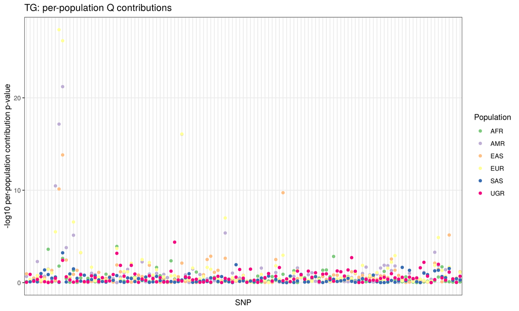

**QQ plot and genomic inflation estimates for per-population Q contributions**

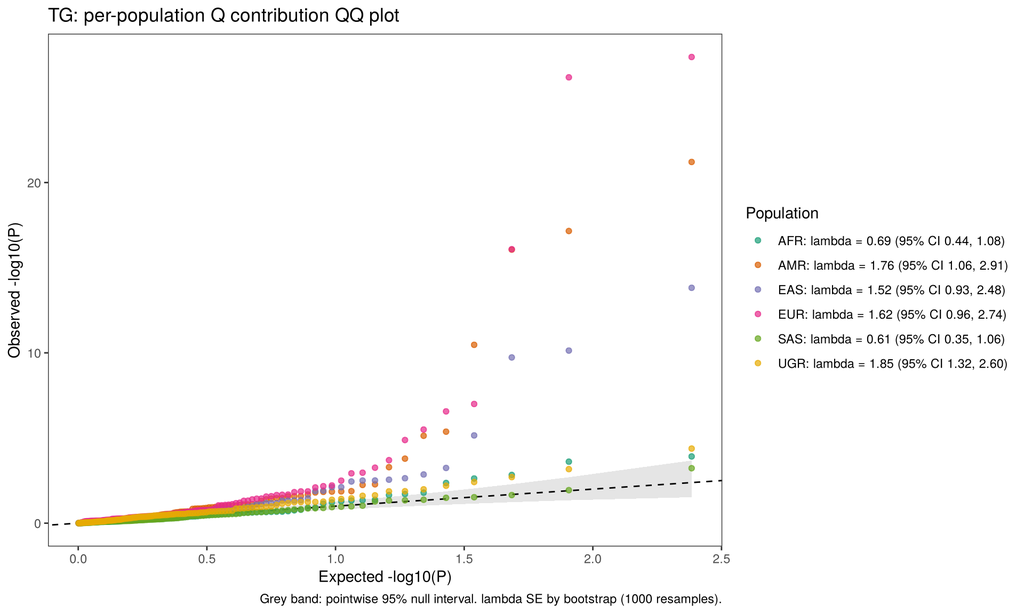

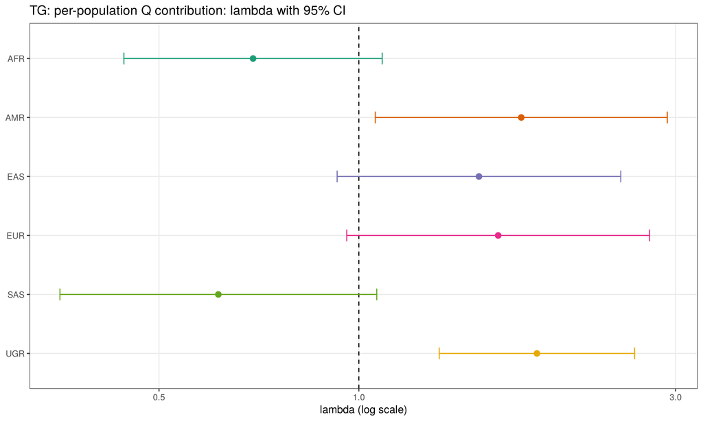

Genomic inflation (lambda) by population with standard error, 95% CI and Wald test of lambda = 1 (CI and test on the log scale; estimates from fewer than ~50 SNPs are imprecise)

| Population | n_snps | lambda | lambda_se | lambda_lci | lambda_uci | p_lambda_eq_1 |
| --- | --- | --- | --- | --- | --- | --- |
| AFR | 121 | 0.693 | 0.158 | 0.443 | 1.084 | 0.108 |
| AMR | 121 | 1.757 | 0.454 | 1.059 | 2.915 | 0.029 |
| EAS | 121 | 1.517 | 0.381 | 0.927 | 2.481 | 0.097 |
| EUR | 121 | 1.621 | 0.434 | 0.959 | 2.741 | 0.071 |
| SAS | 121 | 0.614 | 0.172 | 0.355 | 1.064 | 0.082 |
| UGR | 121 | 1.855 | 0.321 | 1.322 | 2.602 | 0.000 |

**Population-specific estimates for Bonferroni-significant SNPs**

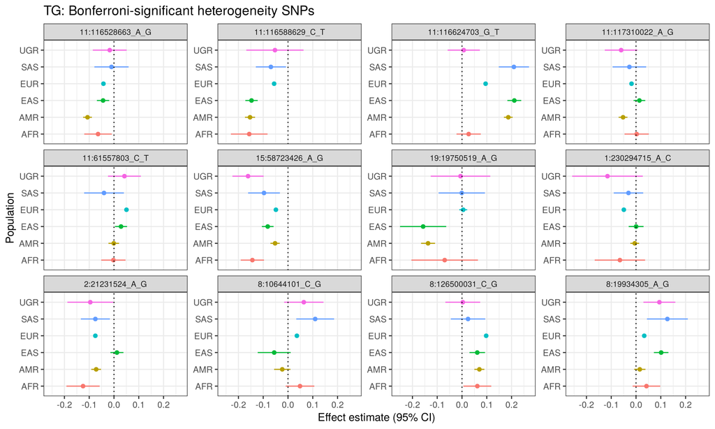

**Population-level Q contribution summary**

| population | variants_with_estimate | fraction_contribution_p_lt_0_05 |
| --- | --- | --- |
| EUR | 121 | 0.231 |
| AMR | 121 | 0.198 |
| EAS | 121 | 0.165 |
| UGR | 121 | 0.107 |
| AFR | 121 | 0.091 |
| SAS | 121 | 0.066 |

### 3.6.1 Expected versus observed replication: all exposure SNPs

EUR discovery SNPs with p < 5e-08; replication significance alpha = 0.05

| comparison | n_discovery | n_paired | nsnp | metric | datum | value | pdiff |
| --- | --- | --- | --- | --- | --- | --- | --- |
| EUR vs AFR | 108 | 108 | 108 | Sign | Expected | 84.32871 | NA |
| EUR vs AFR | 108 | 108 | 108 | Sign | Observed | 95.00000 | 0.01044 |
| EUR vs AFR | 108 | 108 | 108 | P-value | Expected | 20.15223 | NA |
| EUR vs AFR | 108 | 108 | 108 | P-value | Observed | 21.00000 | 0.80535 |
| EUR vs AMR | 108 | 108 | 108 | Sign | Expected | 103.59522 | NA |
| EUR vs AMR | 108 | 108 | 108 | Sign | Observed | 104.00000 | 1.00000 |
| EUR vs AMR | 108 | 108 | 108 | P-value | Expected | 61.60659 | NA |
| EUR vs AMR | 108 | 108 | 108 | P-value | Observed | 54.00000 | 0.14554 |
| EUR vs EAS | 108 | 108 | 108 | Sign | Expected | 98.97604 | NA |
| EUR vs EAS | 108 | 108 | 108 | Sign | Observed | 91.00000 | 0.01303 |
| EUR vs EAS | 108 | 108 | 108 | P-value | Expected | 45.97828 | NA |
| EUR vs EAS | 108 | 108 | 108 | P-value | Observed | 37.00000 | 0.09761 |
| EUR vs SAS | 108 | 108 | 108 | Sign | Expected | 82.41590 | NA |
| EUR vs SAS | 108 | 108 | 108 | Sign | Observed | 87.00000 | 0.36489 |
| EUR vs SAS | 108 | 108 | 108 | P-value | Expected | 17.81681 | NA |
| EUR vs SAS | 108 | 108 | 108 | P-value | Observed | 15.00000 | 0.51911 |
| EUR vs UGR | 108 | 108 | 108 | Sign | Expected | 79.09186 | NA |
| EUR vs UGR | 108 | 108 | 108 | Sign | Observed | 80.00000 | 0.91367 |
| EUR vs UGR | 108 | 108 | 108 | P-value | Expected | 14.27781 | NA |
| EUR vs UGR | 108 | 108 | 108 | P-value | Observed | 28.00000 | 0.00050 |

**Variants with expected-but-not-observed replication**

| comparison | snpid | expected_power | observed_sig | replication_fail | expected_sign | observed_sign | sign_fail |
| --- | --- | --- | --- | --- | --- | --- | --- |
| EUR vs AFR | 11:116624703_G_T | 0.96769 | FALSE | TRUE | 0.99993 | TRUE | FALSE |
| EUR vs AFR | 11:61557803_C_T | 0.52254 | FALSE | FALSE | 0.97812 | FALSE | TRUE |
| EUR vs AMR | 11:61557803_C_T | 0.99605 | FALSE | TRUE | 1.00000 | FALSE | TRUE |
| EUR vs AMR | 19:49259529_A_G | 0.56439 | FALSE | FALSE | 0.98308 | FALSE | TRUE |
| EUR vs AMR | 1:230294715_A_C | 0.99970 | FALSE | TRUE | 1.00000 | TRUE | FALSE |
| EUR vs AMR | 6:32587213_C_T | 0.95992 | FALSE | TRUE | 0.99990 | TRUE | FALSE |
| EUR vs AMR | 8:10644101_C_G | 0.57005 | FALSE | FALSE | 0.98368 | FALSE | TRUE |
| EUR vs EAS | 11:63862882_C_G | 0.97513 | FALSE | TRUE | 0.99996 | TRUE | FALSE |
| EUR vs EAS | 19:8616392_C_T | 0.59440 | FALSE | FALSE | 0.98605 | FALSE | TRUE |
| EUR vs EAS | 1:230294715_A_C | 0.89368 | FALSE | FALSE | 0.99933 | FALSE | TRUE |
| EUR vs EAS | 2:165528876_C_T | 0.49393 | FALSE | FALSE | 0.97409 | FALSE | TRUE |
| EUR vs EAS | 2:21231524_A_G | 0.99986 | FALSE | TRUE | 1.00000 | FALSE | TRUE |
| EUR vs EAS | 6:32587213_C_T | 0.86350 | FALSE | FALSE | 0.99888 | FALSE | TRUE |
| EUR vs EAS | 9:86583076_C_T | 0.39064 | FALSE | FALSE | 0.95371 | FALSE | TRUE |

### 3.6.2 Drug-target subset heterogeneity

Tests: 8; Bonferroni threshold: 0.00625; significant SNPs: 0

**Summary by drug class**

| Drug | n_snps | n_nominal_Q_p_lt_0_05 | n_bonferroni_significant | proportion_FDR_lt_0_05 | median_Q_p | median_FDR | min_FDR |
| --- | --- | --- | --- | --- | --- | --- | --- |
| Ezetimibe | 2 | 1 | 0 | 0 | 0.2813 | 0.4399 | 0.1555 |
| Statins | 6 | 0 | 0 | 0 | 0.3677 | 0.6310 | 0.5123 |

**Drug-target SNPs passing this subset’s Bonferroni threshold**

| snpid | Drug | n_pop | beta_fixed | se_fixed | Q | Qdf | Qpval | fdr |
| --- | --- | --- | --- | --- | --- | --- | --- | --- |

**Nominal drug-target heterogeneity: per-population Q contributions**

| AFR | AMR | EAS | EUR | SAS | UGR | snpid | Drug |
| --- | --- | --- | --- | --- | --- | --- | --- |
| 0.83677 | 0.07886 | 0.66693 | 0.56226 | 0.09412 | 0.00635 | 7:44569399_C_G | Ezetimibe |

**Drug-target per-population Q contribution plot**

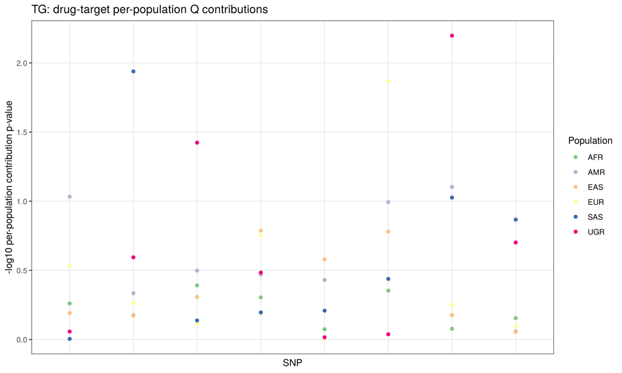

**Drug-target QQ plot and genomic inflation estimates**

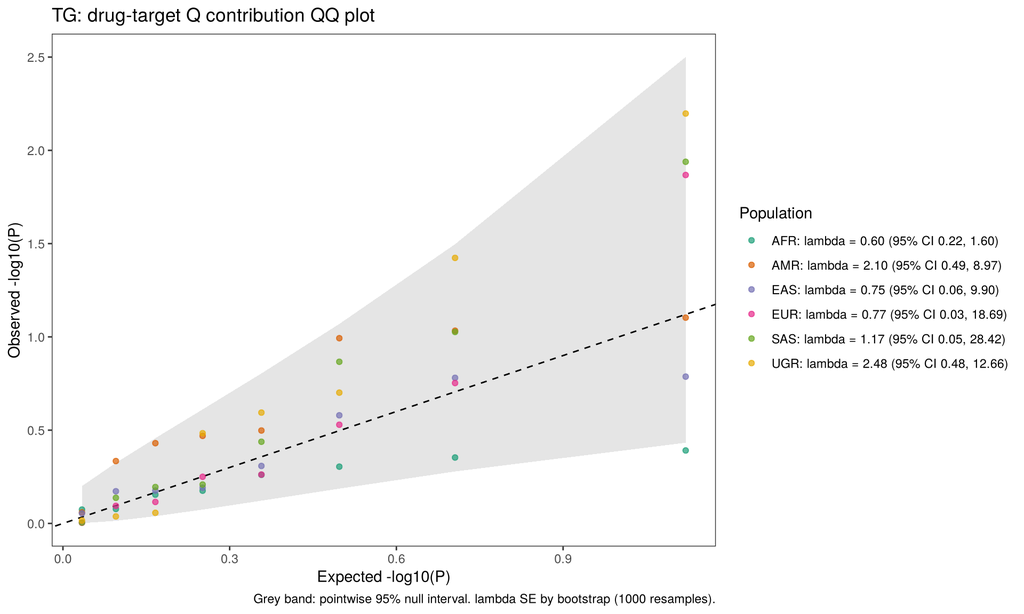

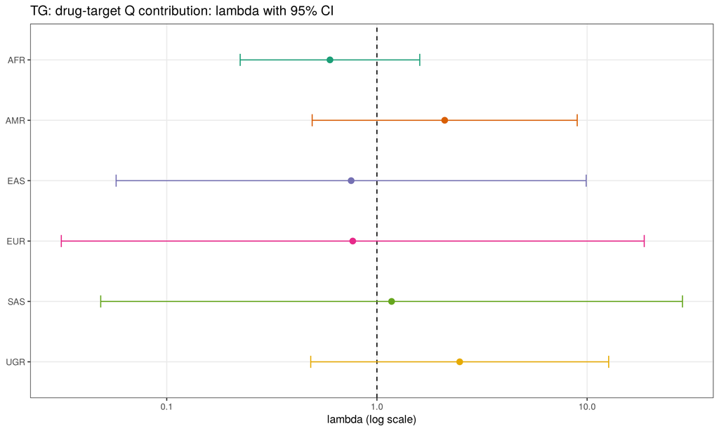

Genomic inflation (lambda) by population with standard error, 95% CI and Wald test of lambda = 1 (CI and test on the log scale; estimates from fewer than ~50 SNPs are imprecise)

| Population | n_snps | lambda | lambda_se | lambda_lci | lambda_uci | p_lambda_eq_1 |
| --- | --- | --- | --- | --- | --- | --- |
| AFR | 8 | 0.598 | 0.300 | 0.224 | 1.599 | 0.305 |
| AMR | 8 | 2.101 | 1.556 | 0.492 | 8.972 | 0.316 |
| EAS | 8 | 0.754 | 0.990 | 0.057 | 9.898 | 0.830 |
| EUR | 8 | 0.767 | 1.250 | 0.032 | 18.693 | 0.871 |
| SAS | 8 | 1.174 | 1.909 | 0.049 | 28.420 | 0.921 |
| UGR | 8 | 2.477 | 2.062 | 0.484 | 12.663 | 0.276 |

**Population-specific estimates for drug-target Bonferroni hits**

No SNPs pass the Bonferroni threshold for this analysis.

**Per-population Q contribution fractions by drug class**

| Drug | population | variants_with_estimate | fraction_contribution_p_lt_0_05 |
| --- | --- | --- | --- |
| Ezetimibe | UGR | 2 | 0.500 |
| Ezetimibe | AFR | 2 | 0.000 |
| Ezetimibe | AMR | 2 | 0.000 |
| Ezetimibe | EAS | 2 | 0.000 |
| Ezetimibe | EUR | 2 | 0.000 |
| Ezetimibe | SAS | 2 | 0.000 |
| Statins | EUR | 6 | 0.167 |
| Statins | SAS | 6 | 0.167 |
| Statins | UGR | 6 | 0.167 |
| Statins | AFR | 6 | 0.000 |
| Statins | AMR | 6 | 0.000 |
| Statins | EAS | 6 | 0.000 |

### 3.6.3 Expected versus observed replication: drug-target SNPs

Drug-target EUR discovery SNPs with p < 0.05; replication significance alpha = 0.05

| comparison | n_discovery | n_paired | nsnp | metric | datum | value | pdiff |
| --- | --- | --- | --- | --- | --- | --- | --- |
| EUR vs AFR | 4 | 4 | 4 | Sign | Expected | 2.37192 | NA |
| EUR vs AFR | 4 | 4 | 4 | Sign | Observed | 2.00000 | 1.00000 |
| EUR vs AFR | 4 | 4 | 4 | P-value | Expected | 0.22813 | NA |
| EUR vs AFR | 4 | 4 | 4 | P-value | Observed | 0.00000 | 1.00000 |
| EUR vs AMR | 4 | 4 | 4 | Sign | Expected | 2.92081 | NA |
| EUR vs AMR | 4 | 4 | 4 | Sign | Observed | 3.00000 | 1.00000 |
| EUR vs AMR | 4 | 4 | 4 | P-value | Expected | 0.41905 | NA |
| EUR vs AMR | 4 | 4 | 4 | P-value | Observed | 2.00000 | 0.05701 |
| EUR vs EAS | 4 | 4 | 4 | Sign | Expected | 2.58735 | NA |
| EUR vs EAS | 4 | 4 | 4 | Sign | Observed | 2.00000 | 0.61769 |
| EUR vs EAS | 4 | 4 | 4 | P-value | Expected | 0.28152 | NA |
| EUR vs EAS | 4 | 4 | 4 | P-value | Observed | 1.00000 | 0.25317 |
| EUR vs SAS | 4 | 4 | 4 | Sign | Expected | 2.24788 | NA |
| EUR vs SAS | 4 | 4 | 4 | Sign | Observed | 2.00000 | 1.00000 |
| EUR vs SAS | 4 | 4 | 4 | P-value | Expected | 0.21258 | NA |
| EUR vs SAS | 4 | 4 | 4 | P-value | Observed | 0.00000 | 1.00000 |
| EUR vs UGR | 4 | 4 | 4 | Sign | Expected | 2.28703 | NA |
| EUR vs UGR | 4 | 4 | 4 | Sign | Observed | 3.00000 | 0.64029 |
| EUR vs UGR | 4 | 4 | 4 | P-value | Expected | 0.21606 | NA |
| EUR vs UGR | 4 | 4 | 4 | P-value | Observed | 1.00000 | 0.19918 |

# 4 Cross-ancestry effect comparison figures

Each panel plots non-European against European effect estimates for the LD-clumped instruments, with every SNP oriented to the European effect-increasing allele, so concordant SNPs lie above zero. The dashed line is y = x and the blue line is the IVW slope through the origin. Grey bars are 95% CIs for the non-European estimates, truncated at the panel limits. Panels in the same row share axis limits. Figures are also saved to `figure_dir` as PDF and PNG.

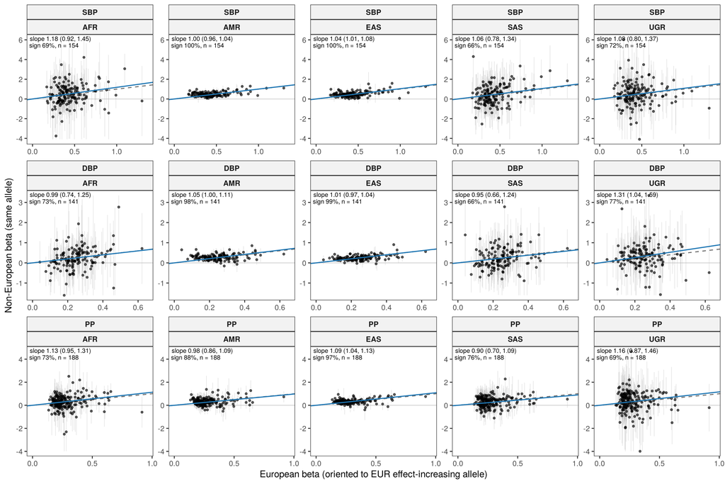

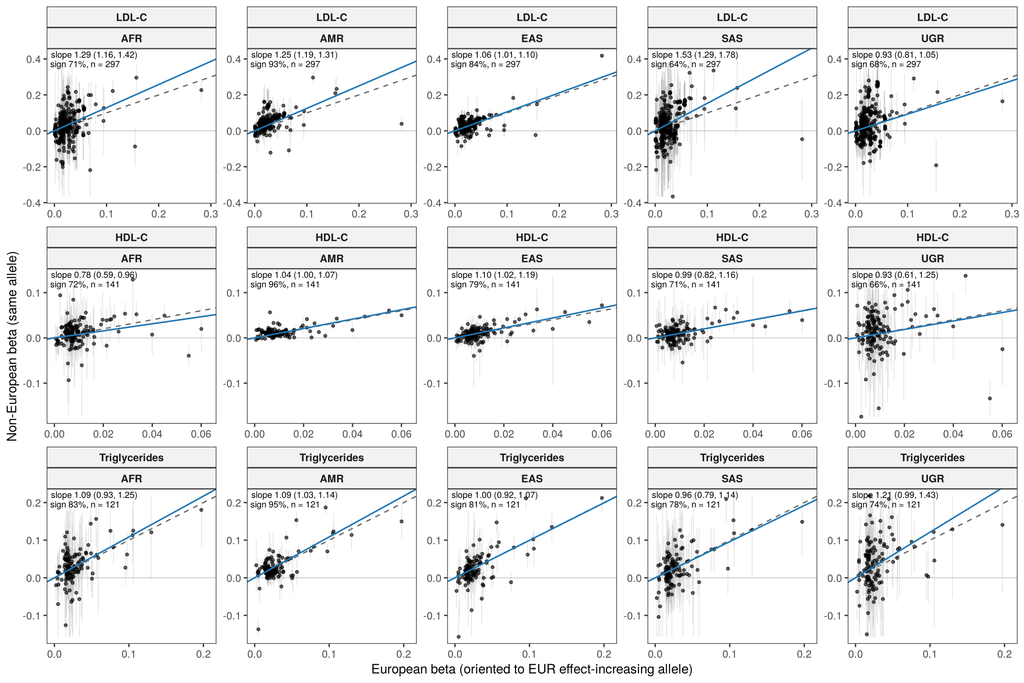

```r
dir.create(figure_dir, showWarnings = FALSE, recursive = TRUE)
for (group in names(figure_groups)) {
  group_traits <- intersect(figure_groups[[group]], names(all_pairs))
  if (!length(group_traits)) next
  p <- plot_cross_ancestry(all_pairs[group_traits], show_ci = show_ci)
  print(p)
  for (ext in c("pdf", "png")) {
    ggsave(file.path(figure_dir, paste0("cross_ancestry_", group, ".", ext)), p,
           width = 12, height = 2.8 * length(group_traits) + 0.6, dpi = 300)
  }
}
```

```r
if (length(all_transferability)) {
  knitr::kable(bind_rows(all_transferability), digits = 3,
               caption = "IVW slope of non-EUR on EUR betas, sign concordance and correlation, by trait and population")
}
```

IVW slope of non-EUR on EUR betas, sign concordance and correlation, by trait and population

| trait | pop | n_snps | ivw_slope | ivw_slope_se | ivw_slope_lci | ivw_slope_uci | sign_concordance | pearson_r |
| --- | --- | --- | --- | --- | --- | --- | --- | --- |
| dbp | AFR | 141 | 0.993 | 0.129 | 0.739 | 1.246 | 0.730 | 0.310 |
| dbp | AMR | 141 | 1.055 | 0.026 | 1.003 | 1.106 | 0.979 | 0.124 |
| dbp | EAS | 141 | 1.006 | 0.018 | 0.971 | 1.042 | 0.986 | 0.439 |
| dbp | SAS | 141 | 0.950 | 0.148 | 0.661 | 1.240 | 0.660 | 0.193 |
| dbp | UGR | 141 | 1.312 | 0.141 | 1.035 | 1.590 | 0.773 | 0.009 |
| hdl | AFR | 141 | 0.778 | 0.095 | 0.593 | 0.964 | 0.723 | 0.210 |
| hdl | AMR | 141 | 1.037 | 0.018 | 1.001 | 1.072 | 0.957 | 0.607 |
| hdl | EAS | 141 | 1.101 | 0.043 | 1.017 | 1.186 | 0.794 | 0.622 |
| hdl | SAS | 141 | 0.993 | 0.087 | 0.823 | 1.162 | 0.709 | 0.473 |
| hdl | UGR | 141 | 0.934 | 0.163 | 0.614 | 1.254 | 0.660 | 0.063 |
| ldlc | AFR | 297 | 1.288 | 0.066 | 1.158 | 1.418 | 0.707 | 0.320 |
| ldlc | AMR | 297 | 1.251 | 0.030 | 1.193 | 1.309 | 0.929 | 0.467 |
| ldlc | EAS | 297 | 1.057 | 0.021 | 1.015 | 1.099 | 0.838 | 0.638 |
| ldlc | SAS | 297 | 1.533 | 0.124 | 1.290 | 1.777 | 0.636 | 0.326 |
| ldlc | UGR | 297 | 0.929 | 0.063 | 0.806 | 1.052 | 0.680 | 0.219 |
| pp | AFR | 188 | 1.131 | 0.092 | 0.950 | 1.312 | 0.734 | 0.125 |
| pp | AMR | 188 | 0.976 | 0.057 | 0.864 | 1.088 | 0.878 | 0.202 |
| pp | EAS | 188 | 1.085 | 0.022 | 1.043 | 1.127 | 0.968 | 0.300 |
| pp | SAS | 188 | 0.898 | 0.099 | 0.703 | 1.093 | 0.755 | 0.173 |
| pp | UGR | 188 | 1.164 | 0.150 | 0.871 | 1.458 | 0.691 | -0.040 |
| sbp | AFR | 154 | 1.182 | 0.136 | 0.915 | 1.448 | 0.688 | 0.150 |
| sbp | AMR | 154 | 1.005 | 0.020 | 0.965 | 1.045 | 1.000 | 0.427 |
| sbp | EAS | 154 | 1.042 | 0.018 | 1.006 | 1.077 | 1.000 | 0.419 |
| sbp | SAS | 154 | 1.058 | 0.142 | 0.779 | 1.337 | 0.656 | 0.334 |
| sbp | UGR | 154 | 1.082 | 0.146 | 0.796 | 1.368 | 0.721 | -0.032 |
| tg | AFR | 121 | 1.086 | 0.082 | 0.926 | 1.246 | 0.835 | 0.532 |
| tg | AMR | 121 | 1.087 | 0.029 | 1.030 | 1.143 | 0.950 | 0.676 |
| tg | EAS | 121 | 0.996 | 0.037 | 0.923 | 1.070 | 0.810 | 0.664 |
| tg | SAS | 121 | 0.960 | 0.089 | 0.785 | 1.136 | 0.777 | 0.586 |
| tg | UGR | 121 | 1.213 | 0.113 | 0.992 | 1.433 | 0.744 | 0.310 |

# 5 Interpretation and reproducibility

For each exposure, Cochran’s Q is calculated from the population-specific estimates using inverse-variance fixed-effect weights. Per-population contribution p-values describe how far each population departs from the others. With `contribution_method = "loo"` (default), each population’s estimate is compared with the IVW estimate of the remaining populations, (beta_j - beta_-j) / sqrt(se_j^2 + se_-j^2), which is ~N(0, 1) under homogeneity for every population. The original Q_j = w_j (beta_j - beta_IVW)^2 statistic (`"qj"`) is deflated for populations that dominate the IVW estimate, such as EUR. Replication uses EUR as the discovery/reference population and compares observed replication with expected rates under the discovery effects and replication sampling variation. Expected significance is the two-sided power at alpha given the discovery effect and the replication SE, and observed significance uses a two-sided replication p-value. Because EUR discovery effects are selected on significance, they may be inflated by winner’s curse, so expected counts are likely upper bounds. Non-EUR estimates in the input files have been rescaled by their slope against EUR (beta / slope, se / slope); this preserves each SNP’s z-statistic, sign and significance, but it means the scatter-plot slopes are close to 1 partly by construction.

```r
cat("Selected traits:", paste(names(files), collapse = ", "), "\n")
```

```
## Selected traits: dbp, hdl, ldlc, pp, sbp, tg
```

```r
cat("Population labels configured:", paste(populations, collapse = ", "), "\n")
```

```
## Population labels configured: AFR, AMR, EAS, EUR, SAS, UGR
```

```r
cat("Overall replication discovery p threshold:", replication_discovery_p, "\n")
```

```
## Overall replication discovery p threshold: 5e-08
```

```r
cat("Drug-target replication discovery p threshold:", drug_replication_discovery_p, "\n")
```

```
## Drug-target replication discovery p threshold: 0.05
```

```r
cat("Per-population contribution method:", contribution_method, "\n")
```

```
## Per-population contribution method: loo
```

```r
cat("Lambda SE method:", lambda_se_method,
    if (lambda_se_method == "bootstrap") paste0("(", lambda_boot_n, " resamples, seed ", lambda_boot_seed, ")") else "", "\n\n")
```

```
## Lambda SE method: bootstrap (1000 resamples, seed 20261127)
```